# Raport 3

Aleksander Milach

12 April 2018

## Zadanie 1

# Podpunkt a

Obliczmy warto??a oczekiwan1 i wariancje rozk3adu wyk3adniczego z parametrem $\lambda$:

$EX=\int_{0}^{\infty} x\lambda e^{-\lambda x}dx=-\frac{e^{-\lambda x}(\lambda x+1)}{\lambda}|_0^\infty =\frac{1}{\lambda}$

$VarX=EX^2-(EX)^2=\int_{0}^{\infty} x^2\lambda e^{-\lambda x}dx-\frac{1}{\lambda^2}=-\frac{e^{-\lambda x}(\lambda^2x^2+2\lambda x+2)}{\lambda^2}|_0^\infty=\frac{2}{\lambda^2}-\frac{1}{\lambda^2}=\frac{1}{\lambda^2}$.

# Podpunkt b

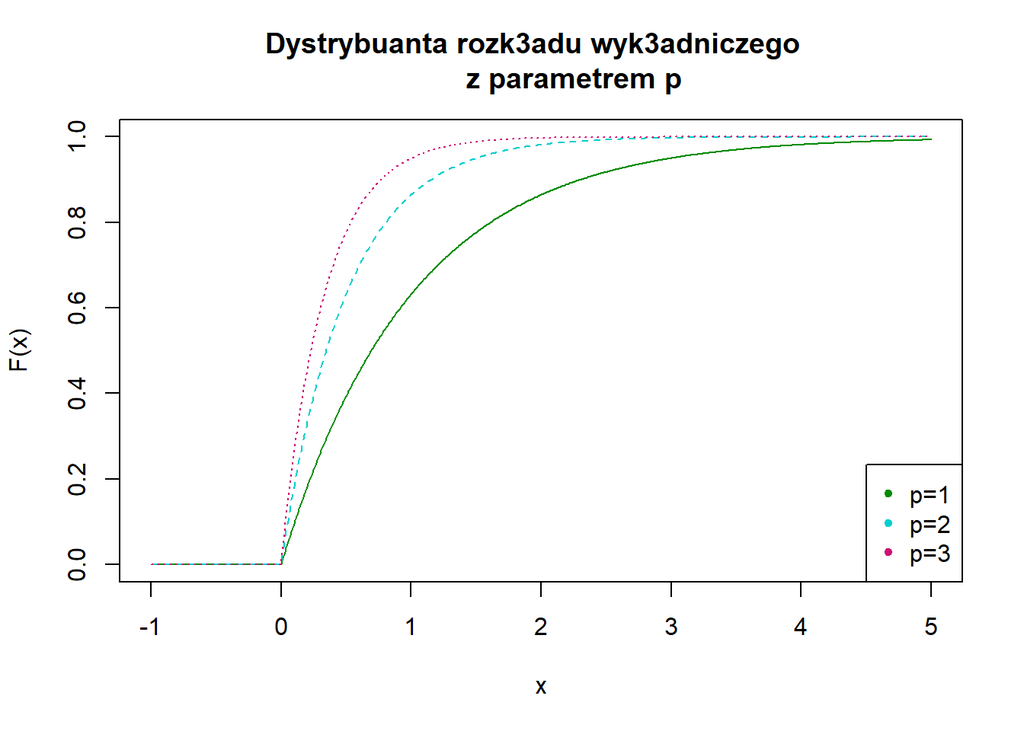

```r
a=seq(-1,5,by=0.01)
matplot(a,cbind(pexp(a,1),pexp(a,2),pexp(a,3)),main="Dystrybuanta rozk3adu wyk3adniczego
        z parametrem p",type="l",xlab="x",ylab="F(x)",col=c("green4","cyan3","deeppink3"))
legend("bottomright",c("p=1","p=2","p=3"), col=c("green4","cyan3","deeppink3"), pch=20)
```

# Podpunkt c

Obliczmy prawdopodobienstwo, ??e zmienna losowa z rozk3adu wyk3adniczego z parametrem $\lambda$=2 wpadnie do odcinka $EX\pm 2\sqrt{VarX}$.

$EX- 2\sqrt{VarX}=\frac{1}{2}-2 \sqrt{ \frac{1}{2^2}}=\frac{1}{2}-2\cdot\frac{1}{2}=-0.5$

$EX+ 2\sqrt{VarX}=\frac{1}{2}+2 \sqrt{ \frac{1}{2^2}}=\frac{1}{2}+2\cdot\frac{1}{2}=1.5$

```r
b=pexp(1.5,2)-pexp(-0.5,2)
```

$P(|X|\leq EX \pm 2\sqrt{VarX})=\int_{-0.5}^{1.5} 2e^{-2x}dx=1-e^{-2x}|_{-0.5}^{1.5}=$ 0.9502129.

# Podpunkt d

```r
d=rexp(1000,2)
f=mean(d>=-0.5&d<=1.5)
```

Wynik obliczen: 0.9502129, wynik na podstawie 1000 elementowej próby losowej: 0.964.

## Zadanie 2

# Podpunkt a

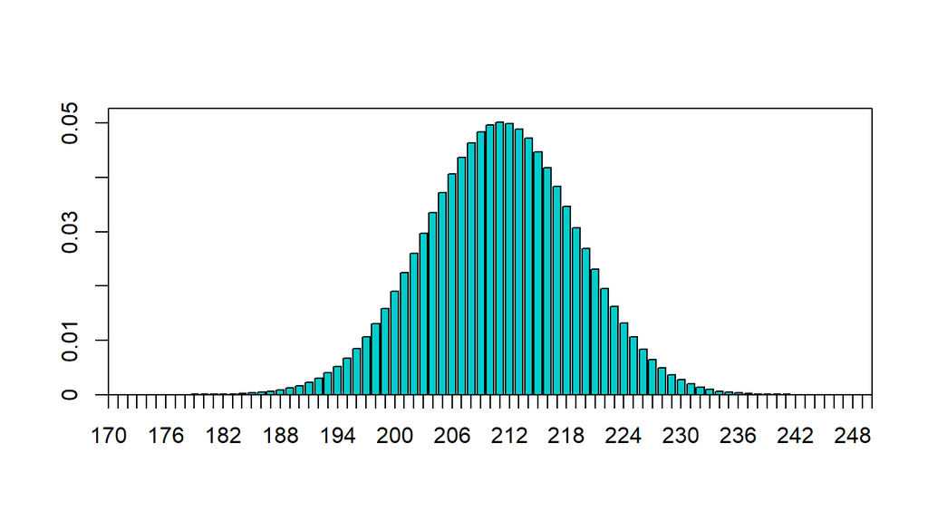

```r
barp(dbinom(0:300,300,0.7),col="cyan3",xlim=c(170,250))
```

# Podpunkt b

```r
g=rbinom(1000,300,0.7)
h=mean(g>=300*0.7-2*sqrt(300*.7*.3) & g<=300*0.7+2*sqrt(300*.7*.3))
j=pbinom(300*0.7+2*sqrt(300*.7*.3),300,.7)-pbinom(300*0.7-2*sqrt(300*.7*.3),300,.7)
```

Prawdopodobienstwo, ??e zmienna losowa z rozk3adu dwumianowego z parametrem 0,7 wpadnie do odcinka $EX\pm 2\sqrt{VarX}$ to 0.9494153. W wygenerowanej 1000 elementowej próbie wpad3o tam 0.948 obserwacji.